## Efficacy analytics audition project

Purpose of this project is to explore the related dataset, and prepare a presentation of any findings and/or actionable insights.

List of assumptions I took during the analysis:

- The missing values are missing at random, that is - value of the variable or any other variable is not related to the fact if the value is input properly or not
- When analyzing mean of average score for different countries, I excluded the countries for which number of student is lower than or equal to 50. That is because it may not be right to compare average for 5 students in one group with average of 1000 students in the other.
- The same student can have two units assigned at the same time (learning two chapters at once), but cannot have two different country codes assigned

The whole process can be divided into sections:  
1. Uploading data and data quality check  
2. Assessing colinearity  
3. Trying to fit linear model to data  
4. Calculating mean of student scores for different countries  
5. Analysis of mean for groups of students, grouped by country and variable in_course

Conclusions will be presented in the end of this file.

1. Uploading data and data quality checks

```r
EAdata <- read.csv("D:/Nauka/R/Pearson zadanie/Audition project/EA_audition_for_sharing/data.csv")
```

Quick look at the data summary and variables classes

```r
summary(EAdata)
```

```
##    learner_id         country      in_course      unit
##  Min.   :     39   TR     :52757   f: 6100   1      :11435
##  1st Qu.:1044868   ES     : 8409   t:75332   2      : 9273
##  Median :1092952   PL     : 5925             3      : 8163
##  Mean   :1137210   CO     : 5537             4      : 7136
##  3rd Qu.:1244376   IT     : 1779             5      : 6448
##  Max.   :1390141   OM     :  856             6      : 5916
##                    (Other): 6169             (Other):33061
##    avg_score        completion        inv_rate
##  Min.   :0.0000   Min.   :0.0250   Min.   :0.00000
##  1st Qu.:0.7170   1st Qu.:0.7000   1st Qu.:0.00000
##  Median :0.8400   Median :0.9620   Median :0.00000
##  Mean   :0.7921   Mean   :0.8098   Mean   :0.04416
##  3rd Qu.:0.9300   3rd Qu.:1.0000   3rd Qu.:0.02300
##  Max.   :1.0000   Max.   :1.0000   Max.   :1.00000
##  NA's   :2
```

```r
nrow(EAdata)
```

```
## [1] 81432
```

```r
for (x in 1:length(EAdata)) {
  print( class(EAdata[,x])  )
}
```

```
## [1] "integer"
## [1] "factor"
## [1] "factor"
## [1] "factor"
## [1] "numeric"
## [1] "numeric"
## [1] "numeric"
```

I performed two simple checks, to know if:

- There are any duplicated rows in the data
- There are any rows where learner with particular id has more than one country assigned

```r
dup<-duplicated(EAdata)
summary(dup)
```

```
##    Mode   FALSE    NA's
## logical   81432       0
```

```r
ids<-unique(EAdata[,1])
for (x in ids) {
  tmp<-unique(EAdata[EAdata$learner_id==x,2])
  if (length(tmp)!=1) {
    print(EAdata[EAdata$learner_id==x,])
  }
}
```

Both checks did not show any issues. The dataset summary also did not depict any issues, so we can move on with the analysis.

2. Checking correlations for different variables

```r
EAdata.3.5<-na.omit(EAdata[,c(3,5)])
cor(as.numeric(EAdata.3.5[,1]),EAdata.3.5[,2])
```

```
## [1] 0.05462745
```

```r
EAdata.5.7<-na.omit(EAdata[,c(5,7)])
cor(as.numeric(EAdata.5.7[,1]),EAdata.5.7[,2])
```

```
## [1] -0.06172509
```

```r
EAdata.4.5<-na.omit(EAdata[,c(4,5)])
cor(as.numeric(EAdata.4.5[,1]),EAdata.4.5[,2])
```

```
## [1] 0.0470316
```

Looks like there is no statisticaly relevant colinearity between avg_score and the variables - inv_rate,unit & in_course

3. Trying to fit linear model to data

```r
model1 <- lm(formula = avg_score ~ as.numeric(in_course) + inv_rate + as.numeric(country),
            data = EAdata)
modelStep <- step(lm(formula = avg_score ~ ., data = EAdata[,-1]))
model2 <- lm(formula = avg_score ~ in_course,  data = EAdata)
```

[output not shown]

None of the models looked useful. Although t-test showed some variables as relevant, there was R^2 statistics showed very weak fit

4. Calculating mean of student scores for different countries

```r
##Calculating mean for of avg_score for each country
library(dplyr)
meanScores<- EAdata %>%
  group_by(country) %>%
  summarise_each(funs(mean(., na.rm=TRUE)), avg_score)
##Let's add to this data frame column with number of student
studentsCountries <- as.data.frame( table(EAdata$country) )
meanScores <- cbind(meanScores, studentsNumber=studentsCountries$Freq)

##Table of mean scores in each country (only those with more than 50 students)
df_meanScores <- as.data.frame(meanScores[meanScores$studentsNumber>50,])
df_meanScores = df_meanScores[ order(df_meanScores$avg_score), ]
```

It turns out, that after filtering out countries number of students higher than 50, we get only 30 countries. Without filtering, it was 87.

Once we have the table of mean scores in filtered countries, we can have a look at it’s top and bottom

```r
head(df_meanScores)
```

```
##    country avg_score studentsNumber
## 37      GB 0.5581979             96
## 50      LT 0.5897941             68
## 60      OM 0.6585362            856
## 69      SA 0.7011261            111
## 13      AU 0.7095208            432
## 58      NL 0.7149567            831
```

```r
tail(df_meanScores)
```

```
##    country avg_score studentsNumber
## 48      KR 0.8241379             58
## 17      BE 0.8280500            180
## 46      IT 0.8314047           1779
## 59      NZ 0.8314787             94
## 10      AR 0.8517416             89
## 81      UA 0.8524843            159
```

We may conclude, that in this ranking students from Ukraine showed the best average score, and students from Great Britian the worst average score

Presenting the top five countries on a bar plot:

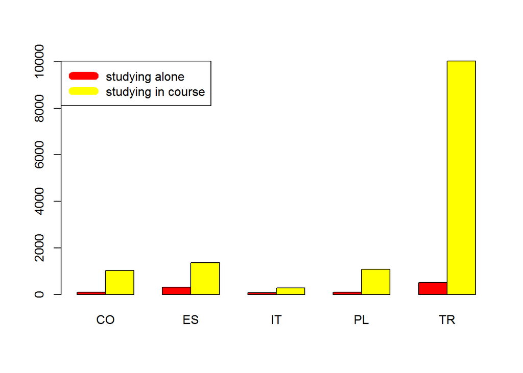

```r
selCountries1000 <- meanScores[meanScores$studentsNumber>1000,1]
EAdataFiltered <- EAdata[EAdata$country == selCountries1000,]
plt<-barplot(table(EAdataFiltered$in_course,as.character( EAdataFiltered$country) ),beside = TRUE, col=c("red","yellow"))
legend("topleft", c("studying alone","studying in course"), lwd=10, col=c("red","yellow"))
```

```r
tab<-table(EAdataFiltered$in_course,as.character( EAdataFiltered$country) )
```

There are only five countries with number of students higher than 1000. Five countries with the highest number of students (total) are presented on the plot.

5. Analysis of mean for groups of students, grouped by country and variable in_course

```r
testMean <- aov(avg_score~country, data = EAdataFiltered)
summary(testMean)
```

```
##                Df Sum Sq Mean Sq F value Pr(>F)
## country         4    6.0  1.4944   41.38 <2e-16 ***
## Residuals   14882  537.5  0.0361
## ---
## Signif. codes:  0 '***' 0.001 '**' 0.01 '*' 0.05 '.' 0.1 ' ' 1
```

```r
TukeyHSD(testMean) #Comparing mean score for each of 5 countries with highest number of students.
```

```
##   Tukey multiple comparisons of means
##     95% family-wise confidence level
##
## Fit: aov(formula = avg_score ~ country, data = EAdataFiltered)
##
## $country
##              diff          lwr          upr     p adj
## ES-CO  0.08249061  0.062485866  0.102495354 0.0000000
## IT-CO  0.10482810  0.073213628  0.136442572 0.0000000
## PL-CO  0.04719057  0.025588745  0.068792399 0.0000000
## TR-CO  0.06454958  0.048249768  0.080849400 0.0000000
## IT-ES  0.02233749 -0.007981899  0.052656879 0.2611453
## PL-ES -0.03530004 -0.054957846 -0.015642230 0.0000096
## TR-ES -0.01794103 -0.031559928 -0.004322125 0.0030153
## PL-IT -0.05763753 -0.089033618 -0.026241438 0.0000055
## TR-IT -0.04027852 -0.068292076 -0.012264956 0.0008371
## TR-PL  0.01735901  0.001486910  0.033231114 0.0238511
```

All the tested pairs of countries has significantly different mean score from each other, except of IT-ES (for 95% confidence level). It is safe to conclude that average scores are different between countries. Are these different for students studying alone and studying with teacher?

```r
selCountries50 <- meanScores[meanScores$studentsNumber>50,1]
EAdataFilteredSmall <- EAdata[EAdata$country == selCountries50,]
testMean <- aov(avg_score~in_course, data = EAdataFilteredSmall)
summary(testMean)
```

```
##               Df Sum Sq Mean Sq F value  Pr(>F)
## in_course      1   0.32  0.3185   8.555 0.00348 **
## Residuals   2670  99.40  0.0372
## ---
## Signif. codes:  0 '***' 0.001 '**' 0.01 '*' 0.05 '.' 0.1 ' ' 1
```

```r
summary(EAdataFilteredSmall[EAdataFilteredSmall$in_course=="t",5])
```

```
##    Min. 1st Qu.  Median    Mean 3rd Qu.    Max.
##  0.0000  0.7250  0.8410  0.7954  0.9330  1.0000
```

```r
summary(EAdataFilteredSmall[EAdataFilteredSmall$in_course=="f",5])
```

```
##    Min. 1st Qu.  Median    Mean 3rd Qu.    Max.
##  0.0000  0.6405  0.7945  0.7520  0.8982  1.0000
```

Again, Anova results show that the difference between groups studying alone and studying in course is statistically significant (for 95% confidence level).

```r
totalMean<-mean(EAdata$avg_score, na.rm = TRUE)
compMeanData<-EAdata[EAdata$avg_score>totalMean,]
print(totalMean)
```

```
## [1] 0.792137
```

```r
median(EAdata$avg_score, na.rm = TRUE)
```

```
## [1] 0.84
```